# ACTG175 Binary Harm Search: Multi-Method Simulation Study

This article runs the simulation study for configuration **`actg175_binary_m1_harm_fs3_methods_both_n700_sims10`** (study = ACTG175, outcome = binary, DGM = m1 [calibrated GLM, target OR(Q) = 2.0], objective = harm, FS bundle = fs3). See `BUNDLE_PATH` in the setup chunk for the exact bundle file used.

The article supports three rendering modes, controlled by `sim_mode` in the setup chunk:

Data preparation, DGM calibration, and a single-trial sanity check always run, regardless of mode, so the tutorial narrative remains intact. In `import` mode the freshly-built DGM objects are overridden with the bundle’s versions to keep the OC tables consistent with the simulation output they describe.

**Libraries, derived locals, echoes (all parameters are in the config-id block)**

```r
library(forestsearch)
library(speff2trial)
```

**Libraries, derived locals, echoes (all parameters are in the config-id block)**

```r
library(data.table)
```

**Libraries, derived locals, echoes (all parameters are in the config-id block)**

```r
library(gt)
library(ggplot2)
library(future)
```

**Libraries, derived locals, echoes (all parameters are in the config-id block)**

```r
library(doFuture)
```

**Libraries, derived locals, echoes (all parameters are in the config-id block)**

```r
library(foreach)

# ALL tunable parameters live in the `config-id` block at the top of the
# document (single source of truth).  This chunk only loads libraries, sets the
# seed, resolves the run mode, derives replicate counts, echoes the active
# settings, and builds a few locals consumed by later chunks.

set.seed(seed_base)

# BUNDLE_PATH / CONFIG_ID are defined in config-id (so they can be referenced
# inline in the article-header prose); reused here without redefinition.
if (sim_mode == "auto") {
  sim_mode <- if (file.exists(BUNDLE_PATH)) "import" else "demo"
}
if (sim_mode == "import" && !file.exists(BUNDLE_PATH)) {
  stop(sprintf("sim_mode = 'import' but no bundle found at '%s'.",
               BUNDLE_PATH), call. = FALSE)
}

# Replicate counts derived from sim_mode (sims_demo / sims_full set in config-id).
nsims_alt <- switch(sim_mode,
  import = 0L, demo = sims_demo, full = sims_full,
  stop(sprintf("Unknown sim_mode: '%s'", sim_mode)))
nsims_null <- switch(sim_mode,
  import = 0L, demo = sims_demo, full = sims_full)

# -- Echo active settings ----------------------------------------------------
cat(sprintf("sim_mode = %s | nsims_alt = %d | nsims_null = %d | sim_n = %d\n",
            sim_mode, nsims_alt, nsims_null, sim_n))
```

```
sim_mode = demo | nsims_alt = 10 | nsims_null = 10 | sim_n = 700
```

**Libraries, derived locals, echoes (all parameters are in the config-id block)**

```r
cat(sprintf(
  "FS thresholds -> screening OR >= %.2f | consistency OR >= %.2f | rate >= %.0f%%\n",
  fs_effect_threshold, fs_consistency_threshold, 100 * fs_pconsistency_threshold))
```

```
FS thresholds -> screening OR >= 1.35 | consistency OR >= 1.00 | rate >= 80%
```

**Libraries, derived locals, echoes (all parameters are in the config-id block)**

```r
# DINA harm floor (m_diff): the dina-* arms set no threshold of their own, so
# they inherit fs_effect_threshold via fs_params.  Inside forestsearch the DINA
# selector maps that screening threshold to the link scale -- log() for ratio
# measures (OR/HR/IRR), identity for difference measures (MD/RD/IRD).  The
# package's own scale test is used so this echo matches what dina_subgroup()
# actually clears.  All three dina-* arms share this floor; they differ only in
# sg_focus / selection_rule / effect_neighborhood.
.dina_identity <- forestsearch:::is_identity_scale(fs_params$effect_measure)
dina_m_diff    <- if (.dina_identity) fs_effect_threshold else log(fs_effect_threshold)
cat(sprintf(
  "DINA harm floor -> m_diff = %.4f  (link scale; %s)\n",
  dina_m_diff,
  if (.dina_identity)
    sprintf("identity = %.4g for %s", fs_effect_threshold, fs_params$effect_measure)
  else
    sprintf("log(%.2f) for %s", fs_effect_threshold, fs_params$effect_measure)))
```

```
DINA harm floor -> m_diff = 0.3001  (link scale; log(1.35) for OR)
```

**Libraries, derived locals, echoes (all parameters are in the config-id block)**

```r
# -- Derived locals consumed by later chunks ---------------------------------
grf_params <- list(
  dmin.grf     = grf_dmin,
  maxdepth     = grf_maxdepth,
  sg.criterion = grf_sg_criterion
)

# Re-exposed for the single-trial sanity-check chunks.
c1       <- fs_params$hr.threshold
max_look <- fs_params$max_subgroups_search

# Display helper: tidy a cut-string for DISPLAY only (rounds full-precision
# numeric thresholds to `digits` significant figures; collapses whitespace,
# leaves integer cuts untouched).  Used by the subgroup-distribution renders.
tidy_sg_def <- function(s, digits = 4L) {
  if (length(s) != 1L || is.na(s) || !nzchar(s)) return(s)
  s <- gsub("[[:space:]]+", " ", s)
  m <- gregexpr("-?[0-9]+\\.[0-9]+", s)[[1L]]
  if (m[1L] == -1L) return(s)
  L <- attr(m, "match.length")
  for (i in rev(seq_along(m))) {
    num <- as.numeric(substr(s, m[i], m[i] + L[i] - 1L))
    rep <- sub("\\.$", "", formatC(signif(num, digits), format = "fg", flag = "#"))
    s <- paste0(substr(s, 1L, m[i] - 1L), rep, substr(s, m[i] + L[i], nchar(s)))
  }
  s
}

# Document-level timing accumulator; each major chunk populates its slot, and
# the bottom-of-document Timing Summary renders the collated values ("—" if unset).
timings <- list()
```

# 1 Purpose

`forestsearch()` (and, since v0.2.0, `dina_subgroup()`) selects among the qualifying candidate subgroups using `sg_focus`. For the effect-anchored foci `"effMaxSG"`/`"effMinSG"` (canonical `"hrMaxSG"`/`"hrMinSG"`), the selection is *not* “take the candidate with the largest effect.” Instead the candidates are first partitioned into a **candidate inclusion band**, and then ranked within that band by sample size. The `selection_rule` argument controls how the band is drawn:

- `"neighborhood"` — a one-dimensional effect band (default).
- `"pareto"` — the two-dimensional Pareto-non-dominated set in (effect, $N$) space.
- `"both"` — the intersection of the two (strictest).

This note explains how the **Pareto frontier** operates: what “dominated” means, how the frontier becomes the `in_pareto` indicator, how it combines with the neighborhood band, and how the resulting `in_band` flag feeds the final selection sort. The single computation shared by every path is `.compute_inclusion_band()`, called by both `sort_subgroups()` (final, post-consistency selection) and `sort_subgroups_preview()` (pre-consistency triage).

# 2 A worked candidate set

Five candidates that have already passed the consistency stage and the effect threshold. Effect on the natural (HR) scale, size $N$:

```r
cands <- data.table(
  id = c("A", "B", "C", "E", "F"),
  hr = c(2.50, 2.40, 2.30, 2.35, 2.00),
  N  = c(70L,  100L, 150L, 90L,  200L)
)

hr_max  <- max(cands$hr)
hr_floor <- (1 - EFFECT_NEIGHBORHOOD) * hr_max

cands[, in_nbhd     := hr >= hr_floor]
cands[, dominated   := dominated_xy(hr, N)]
cands[, on_frontier := !dominated]
cands[, in_both     := in_nbhd & on_frontier]
cands[, status      := fifelse(!in_nbhd, "neither (below floor)",
                        fifelse(in_both,  "both rules",
                                          "neighborhood only"))]

# effMaxSG within the "both" band: largest N among in-band-both candidates.
sel_id <- cands[in_both == TRUE][order(-N)][1L, id]
cands[, selected := id == sel_id]

cands[, .(id, hr, N, in_nbhd, on_frontier, in_both, selected)]
```

```
       id    hr     N in_nbhd on_frontier in_both selected
   <char> <num> <int>  <lgcl>      <lgcl>  <lgcl>   <lgcl>
1:      A  2.50    70    TRUE        TRUE    TRUE    FALSE
2:      B  2.40   100    TRUE        TRUE    TRUE    FALSE
3:      C  2.30   150    TRUE        TRUE    TRUE     TRUE
4:      E  2.35    90    TRUE       FALSE   FALSE    FALSE
5:      F  2.00   200   FALSE        TRUE   FALSE    FALSE
```

With `hr_max = 2.5`, the floor is 2.25. So:

- `A`, `B`, `C` are in the effect band **and** on the frontier — in-band under every rule.
- `E` (HR 2.35, $N$ 90) is in the effect band but **dominated by `B`** (HR 2.40 $\ge$ 2.35 and $N$ 100 $\ge$ 90), so `"pareto"`/`"both"` exclude it while `"neighborhood"` keeps it.
- `F` (HR 2.00, $N$ 200) is on the frontier (largest $N$) but **below the floor**, so `"neighborhood"`/`"both"` exclude it while `"pareto"` keeps it — this is the over-extension guard that the effect band provides and the bare frontier does not.

# 3 The figure

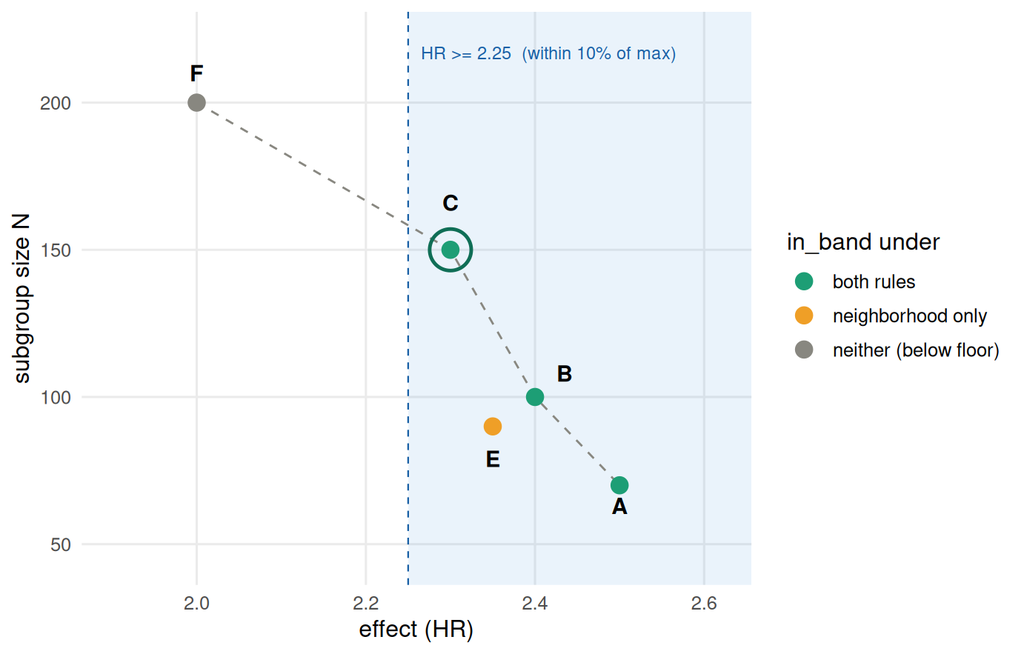

Figure 1: Candidate subgroups in the (effect, N) plane. The shaded region is the effect neighborhood band (HR at least the dashed floor); the dashed line traces the Pareto frontier. Colour encodes which selection_rule keeps each candidate. C is selected by effMaxSG (largest N in the band).

```r
pal <- c("both rules"           = "#1D9E75",
         "neighborhood only"    = "#EF9F27",
         "neither (below floor)" = "#888780")

frontier <- cands[on_frontier == TRUE][order(hr)]

# per-point label offsets so the letters sit clear of points/lines
labs <- data.table(
  id = c("A", "B", "C", "E", "F"),
  lx = c(2.50, 2.435, 2.30, 2.35, 2.00),
  ly = c(63,   108,   166,  79,   210))

ggplot(cands, aes(hr, N)) +
  annotate("rect", xmin = hr_floor, xmax = Inf, ymin = -Inf, ymax = Inf,
           fill = "#378ADD", alpha = 0.10) +
  geom_vline(xintercept = hr_floor, linetype = "dashed",
             colour = "#185FA5", linewidth = 0.4) +
  geom_line(data = frontier, aes(hr, N), linetype = "dashed",
            colour = "#888780", linewidth = 0.5) +
  geom_point(data = cands[selected == TRUE], aes(hr, N),
             shape = 21, size = 9, stroke = 1.3,
             colour = "#0F6E56", fill = NA) +
  geom_point(aes(colour = status), size = 3.6) +
  geom_text(data = labs, aes(lx, ly, label = id),
            size = 4, fontface = "bold") +
  annotate("text", x = hr_floor + 0.015, y = 219,
           label = sprintf("HR >= %.2f  (within %.0f%% of max)",
                           hr_floor, 100 * EFFECT_NEIGHBORHOOD),
           hjust = 0, vjust = 1, size = 3.1, colour = "#185FA5") +
  scale_colour_manual(values = pal, name = "in_band under") +
  scale_x_continuous(limits = c(1.9, 2.62)) +
  scale_y_continuous(limits = c(45, 222)) +
  labs(x = "effect (HR)", y = "subgroup size N") +
  theme_minimal(base_size = 12) +
  theme(legend.position = "right",
        panel.grid.minor = element_blank())
```

Reading the figure: `"neighborhood"` keeps the whole shaded strip $\{A, B, C, E\}$; `"both"` additionally drops `E` because it sits *inside* the frontier (another point beats it on both axes); `"pareto"` alone would keep `F` (top-left, on the frontier) despite its weak effect. The selection then maximizes $N$ within the kept set.

# 4 Data Preparation

**ACTG175 data prep (click to expand)**

```r
# ACTG175: arm 1 = ZDV+ddI (experimental), arm 3 = ddI (control)
actg_df <- subset(speff2trial::ACTG175, arms %in% c(1L, 3L))
actg_df$id <- seq_len(nrow(actg_df))

# Treatment: ZDV+ddI = 1, ddI = 0 (NO switching)
actg_df$treat <- ifelse(actg_df$arms == 1L, 1L, 0L)

# Binary outcome: adverse (failure to improve)
actg_df$y_binary <- as.integer(actg_df$cd420 <= actg_df$cd40)
actg_df <- actg_df[!is.na(actg_df$cd420), ]

# -- DGM factor variables -----------------------------------------------------
# Note that binary and continuous analyses are similar in identified subgroups
# (from observed-data FS result — see companion analysis document)

 actg_df$z1  <- as.factor(ifelse(actg_df$cd40 > 390, 1L, 0L))
 actg_df$z2  <- as.factor(ifelse(actg_df$wtkg > 80, 1L, 0L))

# z7-z12: truly binary indicators (no continuous counterpart)
actg_df$z7  <- as.factor(actg_df$hemo)
actg_df$z8  <- as.factor(actg_df$homo)
actg_df$z9  <- as.factor(actg_df$drugs)
actg_df$z10 <- as.factor(actg_df$race)
actg_df$z11 <- as.factor(actg_df$gender)
actg_df$z12 <- as.factor(actg_df$symptom)

actg_df$ar_naive   <- as.integer(ifelse(actg_df$str2 == 0, 1L, 0L))
actg_df$prior_6mo  <- as.integer(ifelse(actg_df$preanti <= 6 * 30.4375, 1L, 0L))

actg_df$flag_harm_ref <- as.integer(actg_df$z1 == 1 & actg_df$z2 == 1)

# -- Analysis covariates (what the analyst sees) -------------------------------
cont_vars <- c("age", "preanti", "wtkg", "karnof", "cd40", "cd80")
bin_vars  <- c("hemo", "homo", "drugs", "race", "gender", "symptom","ar_naive","prior_6mo")
# Binary confounders kept NUMERIC 0/1: the forestsearch-routed dina-* arms
# require numeric covariates, and grf-* cut-strings (e.g. "symptom <= 0") must
# be numeric to evaluate.  z7-z12 (created above) stay factors for the DGM.
for (v in bin_vars) actg_df[[v]] <- as.integer(actg_df[[v]])
confounders <- c(cont_vars, bin_vars)


# -- DGM variable sets ---------------------------------------------------------
dgm_factor_vars   <- c("z1", "z2", paste0("z", 7:12))
dgm_cont_vars     <- cont_vars
dgm_subgroup_vars <- c("z1", "z2")
dgm_subgroup_cuts <- list(z1 = 1L, z2 = 1L)

# -- Summary -------------------------------------------------------------------
Q_n   <- sum(actg_df$flag_harm_ref)
Q_N   <- nrow(actg_df)
Q_pct <- 100 * Q_n / Q_N

cat(sprintf("N = %d, Q prevalence = %d / %d (%.1f%%)\n", Q_N, Q_n, Q_N, Q_pct))
```

```
N = 1083, Q prevalence = 113 / 1083 (10.4%)
```

**ACTG175 data prep (click to expand)**

```r
cat(sprintf("Adverse rate: overall=%.1f%%, ZDV+ddI=%.1f%%, ddI=%.1f%%\n",
    100 * mean(actg_df$y_binary),
    100 * mean(actg_df$y_binary[actg_df$treat == 1]),
    100 * mean(actg_df$y_binary[actg_df$treat == 0])))
```

```
Adverse rate: overall=39.7%, ZDV+ddI=34.7%, ddI=44.4%
```

# 5 DGM Calibration

Target: OR(Q) = 2 on the adverse scale. The DGM includes factor variables (for subgroup definition) and raw continuous covariates (for a richer prognostic baseline), consistent with the survival `generate_aft_dgm_flex()` design.

```r
dgm_calibrated <- calibrate_glm_interaction(
  data            = actg_df,
  factor_vars     = dgm_factor_vars,
  continuous_vars = dgm_cont_vars,
  outcome_var     = "y_binary",
  treatment_var   = "treat",
  target_effect   = cal_target_or,
  outcome_type    = "binary",
  effect_measure  = "OR",
  subgroup_vars   = dgm_subgroup_vars,
  subgroup_cuts   = dgm_subgroup_cuts,
  k_inter_range   = c(0, 3),
  grid_step       = 0.05,
  n_super         = 5000L,
  seed            = 8316951L,
  verbose         = TRUE
)
```

```
Calibrating: target OR = 2.000 (search target: 2.0000)
  Grid: 0.00 to 3.00 by 0.050 (61 values)
  Best: k_inter = 1.200 -> Effect(Q) = 1.9957 (search target: 2.0000)
=== generate_glm_dgm() ===
  outcome_type:   binary
  effect_measure: OR
  model:          alt
  k_inter:        1.200
  k_treat:        1.000
  n_super:        5000
  n observations: 1083
  factor vars:    8
  continuous vars: 6 (age, preanti, wtkg, karnof, cd40, cd80)

=== Subgroup Definitions ===
   z1 == 1
    Proportion in subgroup: 0.319
   z2 == 1
    Proportion in subgroup: 0.304

Overall subgroup (all conditions met):
  Size: 113 out of 1083
  Proportion: 0.104

Baseline GLM fit (no interaction):
  AIC: 1379.2
  Treatment coefficient: -0.4545 (OR = 0.635)
  Interaction shift (k_inter): 1.2000

=== DGM Summary ===
  Effect(Q):   1.9957  (OR)
  Effect(Qc):  0.6596  (OR)
  Effect(ITT): 0.7501  (OR)
  Subgroup prevalence: 11.0%

Calibration complete: k_inter = 1.200
  Effect(Q):   1.9957  (actual Y scale)
  Effect(Qc):  0.6596
  Effect(ITT): 0.7501
```

```r
cat(sprintf("\n  OR(Q):   %.3f (target: %.1f)\n",
    dgm_calibrated$hazard_ratios$harm_subgroup, cal_target_or))
```

```
  OR(Q):   1.996 (target: 2.0)
```

```r
cat(sprintf("  OR(Qc):  %.3f\n", dgm_calibrated$hazard_ratios$no_harm_subgroup))
```

```
  OR(Qc):  0.660
```

```r
cat(sprintf("  OR(ITT): %.3f\n", dgm_calibrated$hazard_ratios$overall))
```

```
  OR(ITT): 0.750
```

**NoteTrue harm subgroup Q — definition and calibrated effect**

**Definition.** The data-generating harm subgroup is $Q = \{\,\texttt{cd40} > 390 \;\text{and}\; \texttt{wtkg} > 80\,\}$, encoded by the DGM markers `z1` ($\texttt{cd40} > 390$) and `z2` ($\texttt{wtkg} > 80$); a subject belongs to $Q$ only when **both** hold.

**Prevalence.** 113 of 1083 subjects (10.4%) lie in $Q$.

**Calibrated treatment effect** (adverse odds-ratio scale):

- $\operatorname{OR}(Q) =$ 1.996 (target 2.0)
- $\operatorname{OR}(Q^{c}) =$ 0.660
- $\operatorname{OR}(\text{ITT}) =$ 0.750

```r
dgm_null <- generate_glm_dgm(
  data            = actg_df,
  factor_vars     = dgm_factor_vars,
  continuous_vars = dgm_cont_vars,
  outcome_var     = "y_binary",
  treatment_var   = "treat",
  outcome_type    = "binary",
  subgroup_vars   = dgm_subgroup_vars,
  subgroup_cuts   = dgm_subgroup_cuts,
  model           = "null",
  n_super         = 5000L,
  seed            = 8316951L,
  verbose         = TRUE
)
```

```
=== generate_glm_dgm() ===
  outcome_type:   binary
  effect_measure: OR
  model:          null
  k_inter:        0.000
  k_treat:        1.000
  n_super:        5000
  n observations: 1083
  factor vars:    8
  continuous vars: 6 (age, preanti, wtkg, karnof, cd40, cd80)

=== Subgroup Definitions ===
   z1 == 1
    Proportion in subgroup: 0.319
   z2 == 1
    Proportion in subgroup: 0.304

Overall subgroup (all conditions met):
  Size: 113 out of 1083
  Proportion: 0.104

Baseline GLM fit (no interaction):
  AIC: 1379.2
  Treatment coefficient: -0.4545 (OR = 0.635)
  Interaction shift (k_inter): 0.0000 (null model: forced to 0)

=== DGM Summary ===
  Effect(Q):   NA  (OR)
  Effect(Qc):  0.6608  (OR)
  Effect(ITT): 0.6608  (OR)
  Subgroup prevalence: 0.0%
```

# 6 Single Trial Sanity Check

**Single simulated trial + FS analysis alt (click to expand)**

```r
df_sim <- simulate_from_glm_dgm(dgm_calibrated, n = sim_n, seed = 42)
```

**Single simulated trial + FS analysis alt (click to expand)**

```r
itt_fit <- glm(y_sim ~ treat_sim, family = "binomial", data = df_sim)
itt_OR <- exp(coef(itt_fit)["treat_sim"])
itt_event <- with(df_sim,mean(y_sim))

fs_params_single <- fs_params

fs_params_single$show_candidate_summary <- TRUE
fs_params_single$parallel_args$plan <- "multisession"
fs_params_single$parallel_args$workers <- n_workers

fs_single <- do.call(forestsearch, c(
  list(df.analysis = df_sim, confounders.name = confounders),
  fs_params_single
))

if (!is.null(fs_single$sg.harm)) {
  fs_single_tabs <- sg_tables(fs_single, ndecimals = 3)
}

t0 <- proc.time()
fs <- fs_single

if (!is.null(fs$sg.harm)) {
  fs_bc <- forestsearch_bootstrap_dofuture(
    fs.est = fs,
    nb_boots = 500,
    show_three = FALSE,
    details = FALSE,
    parallel_args = list(
      plan = "multisession",
      workers = n_workers,
      show_message = TRUE
    )
  )

  plan("sequential")
  timings$bootstrap_alt <- as.numeric((proc.time() - t0)["elapsed"])

  cat("\nBootstrap completed in",
      round(timings$bootstrap_alt / 60, 1), "minutes\n")

  # Comprehensive summary with diagnostics.  All variables built here are
  # rendered by the small downstream chunks (single-trial-alt-render-*),
  # which exist solely so each gt table is the last (and only) expression
  # of its chunk -- the only way knitr's auto-print reliably emits raw
  # HTML for a gt_tbl object.
  summaries <- summarize_bootstrap_results(
    sgharm = fs$sg.harm,
    boot_results = fs_bc,
    create_plots = TRUE,
    est.scale = "hr"
  )

  ci_tab <- compute_frontier_cis(
    fs,
    n_splits = frontier_params$n_splits,
    seed     = frontier_params$seed
  )

  # Plot rendered inline here -- the graphics-device path is independent
  # of knitr's stdout capture, so print(p) works inside the if-block.
  p <- plot_pareto_frontier(
    fs,
    ci_table  = ci_tab,
    show_band = TRUE,
    xlim      = frontier_params$xlim
  )
  print(p)
}
```

```r
# Define run_loo BEFORE the LOO run chunk so its #| eval: directive can
# reference it.  Chunk options are evaluated before the chunk body, so
# run_loo must already exist in the global env when knitr resolves the
# next chunk's options.
#
# skip_loo is the explicit negation -- defined here so the downstream
# "LOO skipped" note can gate on a plain identifier rather than the
# expression !run_loo, which trips Quarto's YAML validator
# (it parses `!expr !run_loo` as a string, not the expected tagged form).
run_loo   <- !is.null(fs$sg.harm)
skip_loo  <- !run_loo
```

```r
t0 <- proc.time()

# LOO is triggered by Kfolds = N (the function default behavior at
# forestsearch_cross_validation.R:109).  We pass it explicitly here for
# clarity.
N_loo <- nrow(fs$df.est)

fs_loo_result <- forestsearch_Kfold(
  fs.est        = fs,
  Kfolds        = N_loo,
  seedit        = analysis_seed,
  parallel_args = list(
    plan = "multisession",
    workers = n_workers,
    show_message = TRUE
  ),
  details       = FALSE
)

plan("sequential"); gc(verbose = FALSE)
timings$loo_alt <- as.numeric((proc.time() - t0)["elapsed"])

cat("\nLOO completed in", round(timings$loo_alt / 60, 2), "minutes",
    sprintf("(N folds = %d, n_workers = %d)\n", N_loo, n_workers))
```

```r
cat("> **LOO skipped.** No harm subgroup was identified in the ",
    "full-analysis FS run (`fs$sg.harm` is `NULL`), so leave-one-out ",
    "cross-validation has nothing to evaluate.\n", sep = "")
```

### 6.0.1 LOO Summary

```r
cat(cv_summary_text(fs_loo_result, est.scale = "hr"), "\n")
cat(sprintf("Subgroup found in %.0f%% of %d folds.\n",
            fs_loo_result$prop_SG_found, N_loo))
```

### 6.0.2 LOO Tables

The `cv_summary_tables()` helper returns five publication-ready `gt` tables. The first is the combined ITT + subgroup view; the next three are component estimation tables (ITT, full-analysis subgroup, LOO subgroup) that show the underlying treatment-effect estimates with confidence intervals.

```r
loo_out  <- forestsearch_KfoldOut(fs_loo_result, outall = TRUE,
                                  digits = 2)
loo_tabs <- cv_summary_tables(
  loo_out,
  title    = "ACTG175 Leave-One-Out CV Summary (Binary, OR)",
  subtitle = sprintf("ITT and Subgroup Estimates: Full Analysis (FA) vs LOO (N=%d)",
                     N_loo),
  digits   = 2,
  use_gt   = TRUE
)
```

**Single simulated trial + FS analysis Null (click to expand)**

```r
df_sim <- simulate_from_glm_dgm(dgm_null, n = sim_n, seed = 8316951)
```

**Single simulated trial + FS analysis null (click to expand)**

```r
itt_fit <- glm(y_sim ~ treat_sim, family = "binomial", data = df_sim)
itt_OR <- exp(coef(itt_fit)["treat_sim"])
itt_event <- with(df_sim,mean(y_sim))

fs_params_single <- fs_params

fs_params_single$show_candidate_summary <- TRUE
fs_params_single$parallel_args$plan <- "multisession"
fs_params_single$parallel_args$workers <- n_workers

fs_single <- do.call(forestsearch, c(
  list(df.analysis = df_sim, confounders.name = confounders),
  fs_params_single
))

if (!is.null(fs_single$sg.harm)) {
  fs_single_tabs <- sg_tables(fs_single, ndecimals = 3)
}

t0 <- proc.time()
fs <- fs_single

if (!is.null(fs$sg.harm)) {
  fs_bc <- forestsearch_bootstrap_dofuture(
    fs.est = fs,
    nb_boots = 500,
    show_three = FALSE,
    details = FALSE,
    parallel_args = list(
      plan = "multisession",
      workers = n_workers,
      show_message = TRUE
    )
  )

  plan("sequential")
  timings$bootstrap_null <- as.numeric((proc.time() - t0)["elapsed"])

  cat("\nBootstrap completed in",
      round(timings$bootstrap_null / 60, 1), "minutes\n")

  # Comprehensive summary with diagnostics.  All variables built here are
  # rendered by the small downstream chunks (single-trial-null-render-*),
  # which exist solely so each gt table is the last (and only) expression
  # of its chunk -- the only way knitr's auto-print reliably emits raw
  # HTML for a gt_tbl object.
  summaries <- summarize_bootstrap_results(
    sgharm = fs$sg.harm,
    boot_results = fs_bc,
    create_plots = TRUE,
    est.scale = "hr"
  )

  ci_tab <- compute_frontier_cis(
    fs,
    n_splits = frontier_params$n_splits,
    seed     = frontier_params$seed
  )

  # Plot rendered inline here -- the graphics-device path is independent
  # of knitr's stdout capture, so print(p) works inside the if-block.
  p <- plot_pareto_frontier(
    fs,
    ci_table  = ci_tab,
    show_band = TRUE,
    xlim      = frontier_params$xlim
  )
  print(p)
}
```

```r
# Define run_loo BEFORE the LOO run chunk so its #| eval: directive can
# reference it.  Chunk options are evaluated before the chunk body, so
# run_loo must already exist in the global env when knitr resolves the
# next chunk's options.
#
# skip_loo is the explicit negation -- defined here so the downstream
# "LOO skipped" note can gate on a plain identifier rather than the
# expression !run_loo, which trips Quarto's YAML validator
# (it parses `!expr !run_loo` as a string, not the expected tagged form).
run_loo   <- !is.null(fs$sg.harm)
skip_loo  <- !run_loo
```

```r
t0 <- proc.time()

# LOO is triggered by Kfolds = N (the function default behavior at
# forestsearch_cross_validation.R:109).  We pass it explicitly here for
# clarity.
N_loo <- nrow(fs$df.est)

fs_loo_result <- forestsearch_Kfold(
  fs.est        = fs,
  Kfolds        = N_loo,
  seedit        = analysis_seed,
  parallel_args = list(
    plan = "multisession",
    workers = n_workers,
    show_message = TRUE
  ),
  details       = FALSE
)

plan("sequential"); gc(verbose = FALSE)
timings$loo_null <- as.numeric((proc.time() - t0)["elapsed"])

cat("\nLOO completed in", round(timings$loo_null / 60, 2), "minutes",
    sprintf("(N folds = %d, n_workers = %d)\n", N_loo, n_workers))
```

```r
cat("> **LOO skipped.** No harm subgroup was identified in the ",
    "full-analysis FS run (`fs$sg.harm` is `NULL`), so leave-one-out ",
    "cross-validation has nothing to evaluate.\n", sep = "")
```

### 6.0.3 LOO Summary

```r
cat(cv_summary_text(fs_loo_result, est.scale = "hr"), "\n")
cat(sprintf("Subgroup found in %.0f%% of %d folds.\n",
            fs_loo_result$prop_SG_found, N_loo))
```

### 6.0.4 LOO Tables

The `cv_summary_tables()` helper returns five publication-ready `gt` tables. The first is the combined ITT + subgroup view; the next three are component estimation tables (ITT, full-analysis subgroup, LOO subgroup) that show the underlying treatment-effect estimates with confidence intervals.

```r
loo_out  <- forestsearch_KfoldOut(fs_loo_result, outall = TRUE,
                                  digits = 2)
loo_tabs <- cv_summary_tables(
  loo_out,
  title    = "ACTG175 Leave-One-Out CV Summary (Binary, OR)",
  subtitle = sprintf("ITT and Subgroup Estimates: Full Analysis (FA) vs LOO (N=%d)",
                     N_loo),
  digits   = 2,
  use_gt   = TRUE
)
```

# 7 Full Simulation Study

## 7.1 Parameter Lists

**Parallel plan setup (click to expand)**

```r
plan(multisession, workers = n_workers)
cat("Using", n_workers, "parallel workers\n")
```

```
Using 121 parallel workers
```

**Parallel plan setup (click to expand)**

```r
cat("fs_params and grf_params defined in setup chunk\n")
```

```
fs_params and grf_params defined in setup chunk
```

## 7.2 H1 Simulations (Calibrated HTE)

**H1 simulation loop (click to expand)**

```r
cat("Running", nsims_alt, "simulations under H1...\n")
t0 <- proc.time()[3]

results_alt_raw <- foreach(
  sim = seq_len(nsims_alt),
  .errorhandling = "pass",
  .options.future = list(
    packages = c("forestsearch", "survival", "data.table", "future"),
    seed = TRUE
  )
) %dofuture% {
  future::plan("sequential")
  run_simulation_analysis(
    sim_id           = sim,
    dgm              = dgm_calibrated,
    n_sample         = sim_n,
    confounders_base = confounders,
    methods          = METHODS_SPEC,
    fs_params        = fs_params,
    keep             = diag_keep,
    keep_first_n     = diag_keep_first_n,
    verbose          = FALSE
  )
}

t_alt <- proc.time()[3] - t0
results_alt <- collect_results(results_alt_raw, "H1 alt",
                               keep_diagnostics = diag_keep_first_n > 0L)
n_failed_alt <- attr(results_alt, "n_failed")

cat(sprintf("Completed in %.1f min (%d rows, %d failed)\n",
    t_alt / 60, nrow(results_alt), n_failed_alt))
```

## 7.3 H0 Simulations (Null — Homogeneous Effect)

**H0 simulation loop (click to expand)**

```r
cat("Running", nsims_null, "simulations under H0...\n")
t0 <- proc.time()[3]

results_null_raw <- foreach(
  sim = seq_len(nsims_null),
  .errorhandling = "pass",
  .options.future = list(
    packages = c("forestsearch", "survival", "data.table", "future"),
    seed = TRUE
  )
) %dofuture% {
  future::plan("sequential")
  run_simulation_analysis(
    sim_id           = sim,
    dgm              = dgm_null,
    n_sample         = sim_n,
    confounders_base = confounders,
    methods          = METHODS_SPEC,
    fs_params        = fs_params,
    verbose          = FALSE
  )
}

t_null <- proc.time()[3] - t0
results_null <- collect_results(results_null_raw, "H0 null")
n_failed_null <- attr(results_null, "n_failed")

cat(sprintf("Completed in %.1f min (%d rows, %d failed)\n",
    t_null / 60, nrow(results_null), n_failed_null))
```

## 7.4 Save Bundle (full mode only)

**Bundle assembly + saveRDS (click to expand)**

```r
bundle <- list(
  meta = list(
    config_id         = CONFIG_ID,
    timestamp         = Sys.time(),
    n_alt             = nsims_alt,
    n_null            = nsims_null,
    sim_n             = sim_n,
    confounders       = confounders,
    fs_params         = fs_params,
    grf_params        = grf_params,
    methods_spec      = METHODS_SPEC,
    flagship_arm      = FLAGSHIP_ARM,
    diag_keep         = diag_keep,
    diag_keep_first_n = diag_keep_first_n,
    t_alt_sec         = unname(t_alt),
    t_null_sec        = unname(t_null),
    n_failed_alt      = attr(results_alt,  "n_failed"),
    n_failed_null     = attr(results_null, "n_failed"),
    package_version   = as.character(utils::packageVersion("forestsearch")),
    sessionInfo       = utils::sessionInfo()
  ),
  dgm = list(
    calibrated = dgm_calibrated,
    null       = dgm_null
  ),
  results = list(
    alt  = results_alt,
    null = results_null
  )
)

saveRDS(bundle, BUNDLE_PATH)
cat(sprintf("Bundle saved to: %s\n", BUNDLE_PATH))
cat(sprintf("  H1: %.1f min, %d rows, %d failed\n",
            t_alt  / 60, nrow(results_alt),  n_failed_alt))
cat(sprintf("  H0: %.1f min, %d rows, %d failed\n",
            t_null / 60, nrow(results_null), n_failed_null))
```

## 7.5 Mode Handoff

**Bundle import or sim-result handoff (click to expand)**

```r
if (sim_mode == "import") {
  bundle <- readRDS(BUNDLE_PATH)

  # Override the freshly-built DGMs with the bundle's versions so that
  # downstream OC tables match the simulation results they describe.
  dgm_calibrated <- bundle$dgm$calibrated
  dgm_null       <- bundle$dgm$null

  results_alt    <- bundle$results$alt
  results_null   <- bundle$results$null
  t_alt          <- bundle$meta$t_alt_sec
  t_null         <- bundle$meta$t_null_sec
  nsims_alt      <- bundle$meta$n_alt
  nsims_null     <- bundle$meta$n_null
  n_failed_alt   <- bundle$meta$n_failed_alt
  n_failed_null  <- bundle$meta$n_failed_null

  cat(sprintf("Imported bundle: %s\n", BUNDLE_PATH))
  cat(sprintf("  config_id : %s\n", bundle$meta$config_id))
  cat(sprintf("  timestamp : %s\n", format(bundle$meta$timestamp)))
  cat(sprintf("  n_alt     : %d (failed: %d)\n",
              nsims_alt, n_failed_alt))
  cat(sprintf("  n_null    : %d (failed: %d)\n",
              nsims_null, n_failed_null))
  if (!is.null(bundle$meta$package_version)) {
    cat(sprintf("  forestsearch %s\n", bundle$meta$package_version))
  }
  if (!is.null(bundle$meta$config_id) &&
      bundle$meta$config_id != CONFIG_ID) {
    warning(sprintf(
      "Bundle config_id ('%s') does not match this article ('%s').",
      bundle$meta$config_id, CONFIG_ID
    ), call. = FALSE)
  }
} else {
  cat(sprintf("Inline simulation complete (%s mode).\n", sim_mode))
}
```

```
Inline simulation complete (demo mode).
```

# 8 Results

## 8.1 Metrics Glossary

Classification metrics follow the definitions in León et al. (2024, Section 3).

### 8.1.1 Detection

**Found** ($\text{any}(Q)$): proportion of simulations where the method identifies *any* harm subgroup ($\texttt{any.H} = 1$).

- **Under H1** (alternative): $Q$ exists with a differential treatment effect. $\text{any}(Q)$ is **detection power**.
- **Under H0** (null): $Q = \emptyset$ and $Q^c$ is the ITT population. $\text{any}(Q)$ is the **false positive rate (FPR)** for falsely declaring that a harm subgroup exists.

### 8.1.2 Classification Under H1

$$\text{sens}(\hat{Q}) = \frac{\#\{i \in \hat{Q} \cap Q\}}{\#\{i \in Q\}},
\quad
\text{ppv}(\hat{Q}) = \frac{\#\{i \in \hat{Q} \cap Q\}}{\#\{i \in \hat{Q}\}},$$

with analogous measures for the complement $\hat{Q}^c$.

The operating-characteristics tables report these as:

| Table column | León et al. notation | Interpretation |
| --- | --- | --- |
| **Sen** | $\text{sens}(\hat{Q})$ | Fraction of true $Q$ captured by $\hat{Q}$ |
| **Spec** | $\text{sens}(\hat{Q}^c)$ | Fraction of true $Q^c$ correctly in $\hat{Q}^c$ |
| **PPV** | $\text{ppv}(\hat{Q})$ | Fraction of $\hat{Q}$ truly in $Q$ |
| **NPV** | $\text{ppv}(\hat{Q}^c)$ | Fraction of $\hat{Q}^c$ truly in $Q^c$ |

Classification metrics are averaged across **all** simulations (León et al. 2024, Table 1). When no subgroup is detected ($\hat{Q} = \emptyset$), the simulation contributes $\text{sens}(\hat{Q}) = 0$ and $\text{ppv}(\hat{Q}) = 0$ (since no member of $Q$ is captured and no subjects are assigned to $\hat{Q}$). This convention is implemented at the source in `run_simulation_analysis()`, matching the original `fs.estimates.out()` function used in León et al. (2024).

**NoteClassification metrics with discovered cuts**

### 8.1.3 Classification Under H0

Under the null, $Q = \emptyset$ — no subgroup with a differential treatment effect exists. The complement $Q^c$ is the entire ITT population. Per León et al. (2024, Section 3), $\text{sens}(\hat{Q})$ is **undefined** (shown as “—” in the table) and $\text{ppv}(\hat{Q}) \equiv 0$. For the complement, $\text{sens}(\hat{Q}^c) = |\hat{Q}^c|/N$ and $\text{ppv}(\hat{Q}^c) = 1$ since $Q^c$ = ITT.

The only operationally meaningful metric under H0 is the **detection rate (FPR)**.

### 8.1.4 Effect Estimates

All effect estimates are on the adverse scale: OR $> 1$ = treatment (ZDV+ddI) increases the adverse outcome (non-improvement) = **harm**. No inversion or treatment switching is applied.

# 9 Operating Characteristics

## 9.1 H1: Detection + Classification

```r
format_oc_results(
  results_alt,
  metrics   = c("detection", "classification", "subgroup_size"),
  digits    = 2,
  digits_hr = 2,
  title     = "ACTG175 Binary: Harm Subgroup Identification",
  dgm = dgm_calibrated,
  subgroup_notation = sg_notation
)
```

ACTG175 Binary: Harm Subgroup Identification

10 sims, OR(H) = 2.00, OR(Hᶜ) = 0.66

| Method | Sims | Found | Classification Sen | Classification Spec | Classification PPV | Classification NPV | Identified Harm Subgroup Size avg\|Ĥ\| | Identified Harm Subgroup Size min\|Ĥ\| | Identified Harm Subgroup Size max\|Ĥ\| |
| --- | --- | --- | --- | --- | --- | --- | --- | --- | --- |
| fs-eff | 10 | 0.90 | 0.27 | 0.89 | 0.23 | 0.92 | 93 | 71 | 134 |
| fs-effMaxSG | 10 | 0.90 | 0.22 | 0.88 | 0.19 | 0.91 | 97 | 71 | 134 |
| fs-effMinSG | 10 | 0.90 | 0.26 | 0.90 | 0.25 | 0.92 | 84 | 71 | 119 |
| dina-eff | 10 | 0.60 | 0.12 | 0.88 | 0.10 | 0.94 | 90 | 80 | 122 |
| dina-effMaxSG | 10 | 0.60 | 0.12 | 0.86 | 0.08 | 0.94 | 114 | 85 | 184 |
| dina-effMinSG | 10 | 0.60 | 0.12 | 0.88 | 0.10 | 0.94 | 90 | 80 | 122 |
| grf-eff | 10 | 1.00 | 0.14 | 0.89 | 0.15 | 0.89 | 80 | 70 | 91 |
| grf-effMaxSG | 10 | 1.00 | 0.22 | 0.89 | 0.19 | 0.90 | 88 | 70 | 112 |
| grf-effMinSG | 10 | 1.00 | 0.14 | 0.89 | 0.15 | 0.89 | 77 | 70 | 90 |
| grf-tree | 10 | 0.90 | 0.43 | 0.77 | 0.19 | 0.93 | 188 | 114 | 350 |

### 9.1.1 True Subgroup Sizes Across Replicates

```r
# One row per replicate-method combination, but sizeH_true is identical
# across method rows within the same sim.  Deduplicate on sim.
truth_by_sim <- unique(results_alt[, c("sim", "sizeH_true", "sizeHc_true",
                                        "propH_true", "propHc_true")])

callout_Q <- sprintf(
  "|Q|:  mean = %.1f (SD %.2f),  range = [%d, %d],  prop = %.1f%%",
  mean(truth_by_sim$sizeH_true),
  sd(truth_by_sim$sizeH_true),
  min(truth_by_sim$sizeH_true),
  max(truth_by_sim$sizeH_true),
  100 * mean(truth_by_sim$propH_true))

callout_Qc <- sprintf(
  "|Qc|: mean = %.1f (SD %.2f),  range = [%d, %d],  prop = %.1f%%",
  mean(truth_by_sim$sizeHc_true),
  sd(truth_by_sim$sizeHc_true),
  min(truth_by_sim$sizeHc_true),
  max(truth_by_sim$sizeHc_true),
  100 * mean(truth_by_sim$propHc_true))

cat(sprintf("True subgroup sizes across %d H1 replicates (N = %d each):\n",
            nrow(truth_by_sim), sim_n))
```

```
True subgroup sizes across 10 H1 replicates (N = 700 each):
```

```r
cat("  ", callout_Q,  "\n")
```

```
   |Q|:  mean = 77.6 (SD 8.21),  range = [68, 96],  prop = 11.1%
```

```r
cat("  ", callout_Qc, "\n")
```

```
   |Qc|: mean = 622.4 (SD 8.21),  range = [604, 632],  prop = 88.9%
```

**NoteReference sizes for the estimation tables below**

- **|Q| (true harm subgroup)**: mean 77.6 per trial (SD 8.21, range 68–96, average proportion 11.1%).
- **|Qc| (complement)**: mean 622.4 per trial (SD 8.21, range 604–632, average proportion 88.9%).

Compare to $\widehat{|H|}$ (the FS-identified subgroup size) reported in the row-group labels of the estimation tables below. A ratio $\widehat{|H|} \big/ \overline{|Q|} \approx 1$ indicates the method is recovering a subgroup close to the true size; values much smaller suggest FS is identifying a strict subset of $Q$; values larger suggest FS is absorbing some $Q^c$ subjects into $\hat H$.

## 9.2 H1: Estimation Tables

```r
# One estimation table per arm.  gt objects inside a loop need
# as_raw_html() + cat() under results='asis' (auto-print won't fire); a NULL
# return (arm with no estimable subgroup) is skipped.
for (m in METHODS) {
  tbl <- build_estimation_table(
    results         = results_alt,
    dgm             = dgm_calibrated,
    analysis_method = m,
    subgroup_notation = sg_notation,
    title           = sprintf("%s: Effect Estimates Under H1", m)
  )
  if (!is.null(tbl)) cat(gt::as_raw_html(tbl), "\n\n")
}
```

fs-eff: Effect Estimates Under H1

fs-eff: 9/10 (90%) estimable

|  | Avg | SD | Min | Max | b‡ (%) | b† (%) |
| --- | --- | --- | --- | --- | --- | --- |
| Ĥ: 9 estimable, avg \|Ĥ\| = 93, θ†(H) = 2, θ‡(H) = 2.11 |  |  |  |  |  |  |
| θ̂(Ĥ) | 2.37 | 0.61 | 1.90 | 3.51 | 12.25 | 18.54 |
| âhr(Ĥ) | 0.89 | 0.25 | 0.66 | 1.44 | NA | -55.37 |
| θ‡(Ĥ) | 1.07 | 0.37 | 0.63 | 1.84 | NA | -49.31 |
| Ĥᶜ: avg \|Ĥᶜ\| = 607, θ†(Hᶜ) = 0.66, θ‡(Hᶜ) = 0.63 |  |  |  |  |  |  |
| θ̂(Ĥᶜ) | 0.60 | 0.08 | 0.47 | 0.74 | -4.99 | -8.55 |
| âhr(Ĥᶜ) | 0.73 | 0.03 | 0.67 | 0.77 | NA | 10.89 |
| θ‡(Ĥᶜ) | 0.83 | 0.08 | 0.68 | 0.94 | NA | 31.16 |

θ̂(Ĥ) = plugin OR estimate in identified subgroup; θ̂*(Ĥ) = bootstrap bias-corrected; b† = bias relative to true OR θ† (causal truth); θ‡(Ĥ) = controlled direct effect in identified subgroup; b‡ = bias relative to CDE θ‡

fs-effMaxSG: Effect Estimates Under H1

fs-effMaxSG: 9/10 (90%) estimable

|  | Avg | SD | Min | Max | b‡ (%) | b† (%) |
| --- | --- | --- | --- | --- | --- | --- |
| Ĥ: 9 estimable, avg \|Ĥ\| = 97, θ†(H) = 2, θ‡(H) = 2.11 |  |  |  |  |  |  |
| θ̂(Ĥ) | 2.32 | 0.57 | 1.90 | 3.51 | 9.95 | 16.11 |
| âhr(Ĥ) | 0.83 | 0.14 | 0.66 | 1.06 | NA | -58.47 |
| θ‡(Ĥ) | 0.99 | 0.24 | 0.63 | 1.30 | NA | -52.97 |
| Ĥᶜ: avg \|Ĥᶜ\| = 603, θ†(Hᶜ) = 0.66, θ‡(Hᶜ) = 0.63 |  |  |  |  |  |  |
| θ̂(Ĥᶜ) | 0.60 | 0.07 | 0.47 | 0.70 | -5.90 | -9.44 |
| âhr(Ĥᶜ) | 0.74 | 0.02 | 0.70 | 0.77 | NA | 11.76 |
| θ‡(Ĥᶜ) | 0.85 | 0.06 | 0.77 | 0.95 | NA | 33.41 |

θ̂(Ĥ) = plugin OR estimate in identified subgroup; θ̂*(Ĥ) = bootstrap bias-corrected; b† = bias relative to true OR θ† (causal truth); θ‡(Ĥ) = controlled direct effect in identified subgroup; b‡ = bias relative to CDE θ‡

fs-effMinSG: Effect Estimates Under H1

fs-effMinSG: 9/10 (90%) estimable

|  | Avg | SD | Min | Max | b‡ (%) | b† (%) |
| --- | --- | --- | --- | --- | --- | --- |
| Ĥ: 9 estimable, avg \|Ĥ\| = 84, θ†(H) = 2, θ‡(H) = 2.11 |  |  |  |  |  |  |
| θ̂(Ĥ) | 2.38 | 0.60 | 1.91 | 3.51 | 12.85 | 19.18 |
| âhr(Ĥ) | 0.91 | 0.27 | 0.66 | 1.44 | NA | -54.52 |
| θ‡(Ĥ) | 1.09 | 0.39 | 0.63 | 1.84 | NA | -48.44 |
| Ĥᶜ: avg \|Ĥᶜ\| = 616, θ†(Hᶜ) = 0.66, θ‡(Hᶜ) = 0.63 |  |  |  |  |  |  |
| θ̂(Ĥᶜ) | 0.61 | 0.08 | 0.47 | 0.74 | -4.36 | -7.95 |
| âhr(Ĥᶜ) | 0.73 | 0.03 | 0.67 | 0.77 | NA | 10.93 |
| θ‡(Ĥᶜ) | 0.83 | 0.09 | 0.68 | 0.94 | NA | 30.12 |

θ̂(Ĥ) = plugin OR estimate in identified subgroup; θ̂*(Ĥ) = bootstrap bias-corrected; b† = bias relative to true OR θ† (causal truth); θ‡(Ĥ) = controlled direct effect in identified subgroup; b‡ = bias relative to CDE θ‡

dina-eff: Effect Estimates Under H1

dina-eff: 6/10 (60%) estimable

|  | Avg | SD | Min | Max | b‡ (%) | b† (%) |
| --- | --- | --- | --- | --- | --- | --- |
| Ĥ: 6 estimable, avg \|Ĥ\| = 90, θ†(H) = 2, θ‡(H) = 2.11 |  |  |  |  |  |  |
| θ̂(Ĥ) | 1.23 | 0.67 | 0.64 | 2.45 | -41.51 | -38.23 |
| âhr(Ĥ) | 0.79 | 0.07 | 0.71 | 0.86 | NA | -60.53 |
| θ‡(Ĥ) | 1.03 | 0.22 | 0.80 | 1.36 | NA | -51.12 |
| Ĥᶜ: avg \|Ĥᶜ\| = 610, θ†(Hᶜ) = 0.66, θ‡(Hᶜ) = 0.63 |  |  |  |  |  |  |
| θ̂(Ĥᶜ) | 0.71 | 0.07 | 0.61 | 0.84 | 12.30 | 8.08 |
| âhr(Ĥᶜ) | 0.74 | 0.01 | 0.72 | 0.75 | NA | 11.95 |
| θ‡(Ĥᶜ) | 0.84 | 0.03 | 0.80 | 0.87 | NA | 31.74 |

θ̂(Ĥ) = plugin OR estimate in identified subgroup; θ̂*(Ĥ) = bootstrap bias-corrected; b† = bias relative to true OR θ† (causal truth); θ‡(Ĥ) = controlled direct effect in identified subgroup; b‡ = bias relative to CDE θ‡

dina-effMaxSG: Effect Estimates Under H1

dina-effMaxSG: 6/10 (60%) estimable

|  | Avg | SD | Min | Max | b‡ (%) | b† (%) |
| --- | --- | --- | --- | --- | --- | --- |
| Ĥ: 6 estimable, avg \|Ĥ\| = 114, θ†(H) = 2, θ‡(H) = 2.11 |  |  |  |  |  |  |
| θ̂(Ĥ) | 1.14 | 0.44 | 0.50 | 1.70 | -45.95 | -42.92 |
| âhr(Ĥ) | 0.76 | 0.05 | 0.69 | 0.84 | NA | -61.80 |
| θ‡(Ĥ) | 0.98 | 0.18 | 0.78 | 1.20 | NA | -53.34 |
| Ĥᶜ: avg \|Ĥᶜ\| = 586, θ†(Hᶜ) = 0.66, θ‡(Hᶜ) = 0.63 |  |  |  |  |  |  |
| θ̂(Ĥᶜ) | 0.71 | 0.07 | 0.65 | 0.84 | 12.33 | 8.11 |
| âhr(Ĥᶜ) | 0.74 | 0.01 | 0.73 | 0.75 | NA | 12.25 |
| θ‡(Ĥᶜ) | 0.84 | 0.02 | 0.81 | 0.87 | NA | 32.34 |

θ̂(Ĥ) = plugin OR estimate in identified subgroup; θ̂*(Ĥ) = bootstrap bias-corrected; b† = bias relative to true OR θ† (causal truth); θ‡(Ĥ) = controlled direct effect in identified subgroup; b‡ = bias relative to CDE θ‡

dina-effMinSG: Effect Estimates Under H1

dina-effMinSG: 6/10 (60%) estimable

|  | Avg | SD | Min | Max | b‡ (%) | b† (%) |
| --- | --- | --- | --- | --- | --- | --- |
| Ĥ: 6 estimable, avg \|Ĥ\| = 90, θ†(H) = 2, θ‡(H) = 2.11 |  |  |  |  |  |  |
| θ̂(Ĥ) | 1.23 | 0.67 | 0.64 | 2.45 | -41.51 | -38.23 |
| âhr(Ĥ) | 0.79 | 0.07 | 0.71 | 0.86 | NA | -60.53 |
| θ‡(Ĥ) | 1.03 | 0.22 | 0.80 | 1.36 | NA | -51.12 |
| Ĥᶜ: avg \|Ĥᶜ\| = 610, θ†(Hᶜ) = 0.66, θ‡(Hᶜ) = 0.63 |  |  |  |  |  |  |
| θ̂(Ĥᶜ) | 0.71 | 0.07 | 0.61 | 0.84 | 12.30 | 8.08 |
| âhr(Ĥᶜ) | 0.74 | 0.01 | 0.72 | 0.75 | NA | 11.95 |
| θ‡(Ĥᶜ) | 0.84 | 0.03 | 0.80 | 0.87 | NA | 31.74 |

θ̂(Ĥ) = plugin OR estimate in identified subgroup; θ̂*(Ĥ) = bootstrap bias-corrected; b† = bias relative to true OR θ† (causal truth); θ‡(Ĥ) = controlled direct effect in identified subgroup; b‡ = bias relative to CDE θ‡

grf-eff: Effect Estimates Under H1

grf-eff: 10/10 (100%) estimable

|  | Avg | SD | Min | Max | b‡ (%) | b† (%) |
| --- | --- | --- | --- | --- | --- | --- |
| Ĥ: 10 estimable, avg \|Ĥ\| = 80, θ†(H) = 2, θ‡(H) = 2.11 |  |  |  |  |  |  |
| θ̂(Ĥ) | 2.12 | 0.58 | 1.48 | 2.80 | 0.69 | 6.33 |
| âhr(Ĥ) | 0.77 | 0.13 | 0.65 | 1.08 | NA | -61.41 |
| θ‡(Ĥ) | 0.92 | 0.22 | 0.63 | 1.28 | NA | -56.15 |
| Ĥᶜ: avg \|Ĥᶜ\| = 620, θ†(Hᶜ) = 0.66, θ‡(Hᶜ) = 0.63 |  |  |  |  |  |  |
| θ̂(Ĥᶜ) | 0.62 | 0.08 | 0.49 | 0.76 | -1.69 | -5.39 |
| âhr(Ĥᶜ) | 0.75 | 0.01 | 0.73 | 0.77 | NA | 13.33 |
| θ‡(Ĥᶜ) | 0.86 | 0.04 | 0.80 | 0.91 | NA | 35.78 |

θ̂(Ĥ) = plugin OR estimate in identified subgroup; θ̂*(Ĥ) = bootstrap bias-corrected; b† = bias relative to true OR θ† (causal truth); θ‡(Ĥ) = controlled direct effect in identified subgroup; b‡ = bias relative to CDE θ‡

grf-effMaxSG: Effect Estimates Under H1

grf-effMaxSG: 10/10 (100%) estimable

|  | Avg | SD | Min | Max | b‡ (%) | b† (%) |
| --- | --- | --- | --- | --- | --- | --- |
| Ĥ: 10 estimable, avg \|Ĥ\| = 88, θ†(H) = 2, θ‡(H) = 2.11 |  |  |  |  |  |  |
| θ̂(Ĥ) | 2.04 | 0.47 | 1.64 | 2.80 | -3.14 | 2.29 |
| âhr(Ĥ) | 0.82 | 0.18 | 0.65 | 1.22 | NA | -59.04 |
| θ‡(Ĥ) | 1.00 | 0.26 | 0.63 | 1.47 | NA | -52.40 |
| Ĥᶜ: avg \|Ĥᶜ\| = 612, θ†(Hᶜ) = 0.66, θ‡(Hᶜ) = 0.63 |  |  |  |  |  |  |
| θ̂(Ĥᶜ) | 0.62 | 0.08 | 0.49 | 0.75 | -3.11 | -6.75 |
| âhr(Ĥᶜ) | 0.74 | 0.02 | 0.69 | 0.77 | NA | 12.34 |
| θ‡(Ĥᶜ) | 0.85 | 0.07 | 0.70 | 0.91 | NA | 33.30 |

θ̂(Ĥ) = plugin OR estimate in identified subgroup; θ̂*(Ĥ) = bootstrap bias-corrected; b† = bias relative to true OR θ† (causal truth); θ‡(Ĥ) = controlled direct effect in identified subgroup; b‡ = bias relative to CDE θ‡

grf-effMinSG: Effect Estimates Under H1

grf-effMinSG: 10/10 (100%) estimable

|  | Avg | SD | Min | Max | b‡ (%) | b† (%) |
| --- | --- | --- | --- | --- | --- | --- |
| Ĥ: 10 estimable, avg \|Ĥ\| = 77, θ†(H) = 2, θ‡(H) = 2.11 |  |  |  |  |  |  |
| θ̂(Ĥ) | 2.13 | 0.60 | 1.48 | 2.95 | 1.18 | 6.85 |
| âhr(Ĥ) | 0.77 | 0.13 | 0.65 | 1.08 | NA | -61.26 |
| θ‡(Ĥ) | 0.94 | 0.21 | 0.63 | 1.28 | NA | -55.47 |
| Ĥᶜ: avg \|Ĥᶜ\| = 623, θ†(Hᶜ) = 0.66, θ‡(Hᶜ) = 0.63 |  |  |  |  |  |  |
| θ̂(Ĥᶜ) | 0.63 | 0.08 | 0.49 | 0.76 | -1.06 | -4.77 |
| âhr(Ĥᶜ) | 0.75 | 0.01 | 0.73 | 0.77 | NA | 13.23 |
| θ‡(Ĥᶜ) | 0.86 | 0.04 | 0.80 | 0.91 | NA | 35.13 |

θ̂(Ĥ) = plugin OR estimate in identified subgroup; θ̂*(Ĥ) = bootstrap bias-corrected; b† = bias relative to true OR θ† (causal truth); θ‡(Ĥ) = controlled direct effect in identified subgroup; b‡ = bias relative to CDE θ‡

grf-tree: Effect Estimates Under H1

grf-tree: 9/10 (90%) estimable

|  | Avg | SD | Min | Max | b‡ (%) | b† (%) |
| --- | --- | --- | --- | --- | --- | --- |
| Ĥ: 9 estimable, avg \|Ĥ\| = 188, θ†(H) = 2, θ‡(H) = 2.11 |  |  |  |  |  |  |
| θ̂(Ĥ) | 2.18 | 0.61 | 1.46 | 3.49 | 3.66 | 9.47 |
| âhr(Ĥ) | 0.83 | 0.07 | 0.75 | 0.93 | NA | -58.42 |
| θ‡(Ĥ) | 0.98 | 0.10 | 0.88 | 1.17 | NA | -53.48 |
| Ĥᶜ: avg \|Ĥᶜ\| = 512, θ†(Hᶜ) = 0.66, θ‡(Hᶜ) = 0.63 |  |  |  |  |  |  |
| θ̂(Ĥᶜ) | 0.45 | 0.05 | 0.37 | 0.54 | -28.67 | -31.35 |
| âhr(Ĥᶜ) | 0.72 | 0.02 | 0.68 | 0.74 | NA | 9.31 |
| θ‡(Ĥᶜ) | 0.82 | 0.06 | 0.71 | 0.90 | NA | 28.95 |

θ̂(Ĥ) = plugin OR estimate in identified subgroup; θ̂*(Ĥ) = bootstrap bias-corrected; b† = bias relative to true OR θ† (causal truth); θ‡(Ĥ) = controlled direct effect in identified subgroup; b‡ = bias relative to CDE θ‡

## 9.3 H1: Classification Tables

```r
scenario_alt <- list(
  H1 = list(
    results    = results_alt,
    dgm        = dgm_calibrated,
    hypothesis = "alt",
    n_sample   = sim_n,
    label      = "ACTG175"
  )
)

for (m in METHODS) {
  tbl <- build_classification_table(
    scenario_alt,
    analyses          = m,
    subgroup_notation = sg_notation,
    title             = sprintf("%s: Classification Under H1", m)
  )
  if (!is.null(tbl)) cat(gt::as_raw_html(tbl), "\n\n")
}
```

fs-eff: Classification Under H1

|  | fs.eff |
| --- | --- |
| ACTG175 Alt: N=700, p_H=11%, theta(H)=2, theta(Hc)=0.66, theta(ITT)=0.75 |  |
| any(H) | 0.90 |
| sens(H) | 0.27 |
| sens(Hc) | 0.89 |
| ppv(H) | 0.23 |
| ppv(Hc) | 0.92 |
| avg\|H\| | 93.00 |

fs-effMaxSG: Classification Under H1

|  | fs.effMaxSG |
| --- | --- |
| ACTG175 Alt: N=700, p_H=11%, theta(H)=2, theta(Hc)=0.66, theta(ITT)=0.75 |  |
| any(H) | 0.90 |
| sens(H) | 0.22 |
| sens(Hc) | 0.88 |
| ppv(H) | 0.19 |
| ppv(Hc) | 0.91 |
| avg\|H\| | 97.00 |

fs-effMinSG: Classification Under H1

|  | fs.effMinSG |
| --- | --- |
| ACTG175 Alt: N=700, p_H=11%, theta(H)=2, theta(Hc)=0.66, theta(ITT)=0.75 |  |
| any(H) | 0.90 |
| sens(H) | 0.26 |
| sens(Hc) | 0.90 |
| ppv(H) | 0.25 |
| ppv(Hc) | 0.92 |
| avg\|H\| | 84.00 |

dina-eff: Classification Under H1

|  | dina.eff |
| --- | --- |
| ACTG175 Alt: N=700, p_H=11%, theta(H)=2, theta(Hc)=0.66, theta(ITT)=0.75 |  |
| any(H) | 0.60 |
| sens(H) | 0.12 |
| sens(Hc) | 0.88 |
| ppv(H) | 0.10 |
| ppv(Hc) | 0.94 |
| avg\|H\| | 90.00 |

dina-effMaxSG: Classification Under H1

|  | dina.effMaxSG |
| --- | --- |
| ACTG175 Alt: N=700, p_H=11%, theta(H)=2, theta(Hc)=0.66, theta(ITT)=0.75 |  |
| any(H) | 0.60 |
| sens(H) | 0.12 |
| sens(Hc) | 0.86 |
| ppv(H) | 0.08 |
| ppv(Hc) | 0.94 |
| avg\|H\| | 114.00 |

dina-effMinSG: Classification Under H1

|  | dina.effMinSG |
| --- | --- |
| ACTG175 Alt: N=700, p_H=11%, theta(H)=2, theta(Hc)=0.66, theta(ITT)=0.75 |  |
| any(H) | 0.60 |
| sens(H) | 0.12 |
| sens(Hc) | 0.88 |
| ppv(H) | 0.10 |
| ppv(Hc) | 0.94 |
| avg\|H\| | 90.00 |

grf-eff: Classification Under H1

|  | grf.eff |
| --- | --- |
| ACTG175 Alt: N=700, p_H=11%, theta(H)=2, theta(Hc)=0.66, theta(ITT)=0.75 |  |
| any(H) | 1.00 |
| sens(H) | 0.14 |
| sens(Hc) | 0.89 |
| ppv(H) | 0.15 |
| ppv(Hc) | 0.89 |
| avg\|H\| | 80.00 |

grf-effMaxSG: Classification Under H1

|  | grf.effMaxSG |
| --- | --- |
| ACTG175 Alt: N=700, p_H=11%, theta(H)=2, theta(Hc)=0.66, theta(ITT)=0.75 |  |
| any(H) | 1.00 |
| sens(H) | 0.22 |
| sens(Hc) | 0.89 |
| ppv(H) | 0.19 |
| ppv(Hc) | 0.90 |
| avg\|H\| | 88.00 |

grf-effMinSG: Classification Under H1

|  | grf.effMinSG |
| --- | --- |
| ACTG175 Alt: N=700, p_H=11%, theta(H)=2, theta(Hc)=0.66, theta(ITT)=0.75 |  |
| any(H) | 1.00 |
| sens(H) | 0.14 |
| sens(Hc) | 0.89 |
| ppv(H) | 0.15 |
| ppv(Hc) | 0.89 |
| avg\|H\| | 77.00 |

grf-tree: Classification Under H1

|  | grf.tree |
| --- | --- |
| ACTG175 Alt: N=700, p_H=11%, theta(H)=2, theta(Hc)=0.66, theta(ITT)=0.75 |  |
| any(H) | 0.90 |
| sens(H) | 0.43 |
| sens(Hc) | 0.77 |
| ppv(H) | 0.19 |
| ppv(Hc) | 0.93 |
| avg\|H\| | 188.00 |

## 9.4 H1: Subgroup Distribution

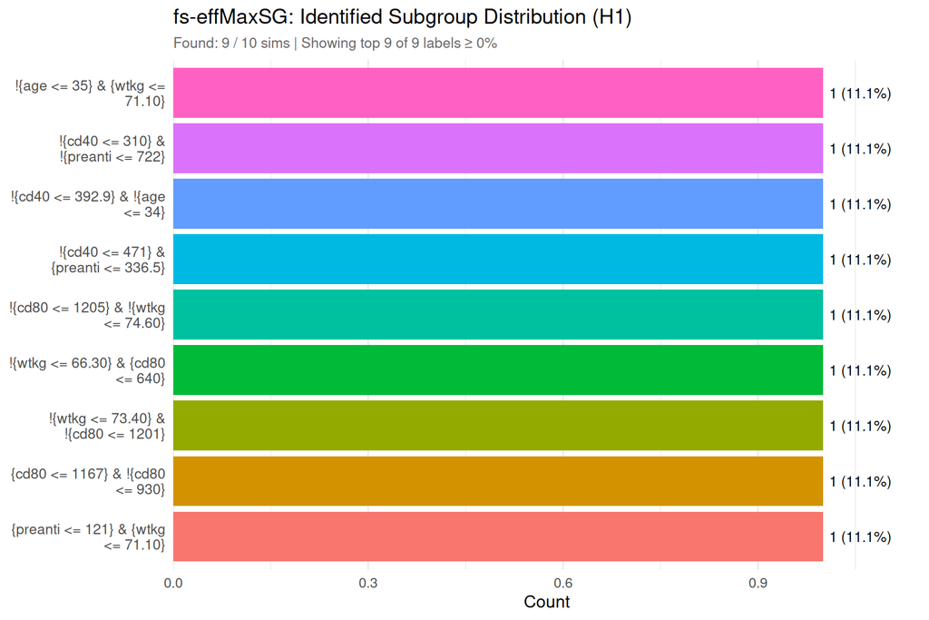

```r
flag_alt <- results_alt[results_alt$analysis == FLAGSHIP_ARM, ]
if (nrow(flag_alt) == 0L || sum(flag_alt$any.H, na.rm = TRUE) == 0L) {
  cat(sprintf("*No detected subgroups for flagship arm `%s` under H1.*\n",
              FLAGSHIP_ARM))
} else {
  flag_alt[["sg.def"]] <- vapply(flag_alt[["sg.def"]], tidy_sg_def,
                                 character(1), USE.NAMES = FALSE)
  print(plot_sg_distribution(
    flag_alt,
    any_col   = "any.H",
    label_col = "sg.def",
    min_pct   = sgdist_min_pct_alt,
    top_k     = sgdist_top_k,
    title     = sprintf("%s: Identified Subgroup Distribution (H1)", FLAGSHIP_ARM)
  ))
}
```

## 9.5 H1: OR Distribution

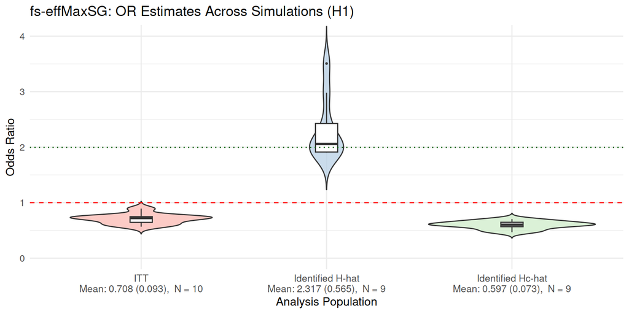

```r
or_Q_true <- dgm_calibrated$hazard_ratios$harm_subgroup

if (sum(results_alt[results_alt$analysis == FLAGSHIP_ARM, ]$any.H,
        na.rm = TRUE) == 0L) {
  cat(sprintf("*No detected subgroups for flagship arm `%s` under H1.*\n",
              FLAGSHIP_ARM))
} else {
  print(plot_effect_distribution(
    results           = results_alt,
    analysis_method   = FLAGSHIP_ARM,
    effect_measure    = "OR",
    subgroup_notation = sg_notation,
    reference_effect  = or_Q_true,
    ylim              = ordist_ylim,
    title             = sprintf("%s: OR Estimates Across Simulations (H1)", FLAGSHIP_ARM)
  ))
}
```

## 9.6 H0: Type I Error

```r
format_oc_results(
  results_null,
  dgm = dgm_null,
  metrics   = c("detection", "classification", "subgroup_size"),
  digits    = 2,
  title     = "ACTG175 Binary: Type I Error (Null)",
   subgroup_notation = sg_notation
)
```

ACTG175 Binary: Type I Error (Null)

10 sims, OR(H) = NA, OR(Hᶜ) = 0.66

| Method | Sims | Found | Classification Sen | Classification Spec | Classification PPV | Classification NPV | Identified Harm Subgroup Size avg\|Ĥ\| | Identified Harm Subgroup Size min\|Ĥ\| | Identified Harm Subgroup Size max\|Ĥ\| |
| --- | --- | --- | --- | --- | --- | --- | --- | --- | --- |
| fs-eff | 10 | 0.90 | - | 0.87 | 0.00 | 1.00 | 101 | 72 | 150 |
| fs-effMaxSG | 10 | 0.90 | - | 0.85 | 0.00 | 1.00 | 113 | 73 | 164 |
| fs-effMinSG | 10 | 0.90 | - | 0.88 | 0.00 | 1.00 | 94 | 72 | 134 |
| dina-eff | 10 | 0.40 | - | 0.95 | 0.00 | 1.00 | 80 | 71 | 85 |
| dina-effMaxSG | 10 | 0.40 | - | 0.94 | 0.00 | 1.00 | 100 | 85 | 136 |
| dina-effMinSG | 10 | 0.40 | - | 0.95 | 0.00 | 1.00 | 80 | 71 | 85 |
| grf-eff | 10 | 0.60 | - | 0.93 | 0.00 | 1.00 | 80 | 70 | 91 |
| grf-effMaxSG | 10 | 0.60 | - | 0.93 | 0.00 | 1.00 | 80 | 70 | 91 |
| grf-effMinSG | 10 | 0.60 | - | 0.93 | 0.00 | 1.00 | 76 | 70 | 90 |
| grf-tree | 10 | 1.00 | - | 0.78 | 0.00 | 1.00 | 154 | 75 | 261 |

## 9.7 H0: Estimation Tables

```r
for (m in METHODS) {
  tbl <- build_estimation_table(
    results         = results_null,
    dgm             = dgm_null,
    analysis_method = m,
    subgroup_notation = sg_notation,
    title           = sprintf("%s: Effect Estimates Under H0", m)
  )
  if (!is.null(tbl)) cat(gt::as_raw_html(tbl), "\n\n")
}
```

fs-eff: Effect Estimates Under H0

fs-eff: 9/10 (90%) estimable

|  | Avg | SD | Min | Max | b‡ (%) | b† (%) |
| --- | --- | --- | --- | --- | --- | --- |
| Ĥ: 9 estimable, avg \|Ĥ\| = 101, θ†(H) = 0.66, θ‡(H) = 0.63 |  |  |  |  |  |  |
| θ̂(Ĥ) | 2.11 | 0.42 | 1.73 | 3.14 | 232.57 | 219.48 |
| âhr(Ĥ) | 0.66 | 0.01 | 0.65 | 0.66 | NA | -0.88 |
| θ‡(Ĥ) | 0.63 | 0.00 | 0.63 | 0.63 | NA | 0.00 |
| Ĥᶜ: avg \|Ĥᶜ\| = 599, θ†(Hᶜ) = 0.66, θ‡(Hᶜ) = 0.63 |  |  |  |  |  |  |
| θ̂(Ĥᶜ) | 0.53 | 0.09 | 0.39 | 0.68 | -16.82 | -20.09 |
| âhr(Ĥᶜ) | 0.66 | 0.00 | 0.66 | 0.66 | NA | -0.05 |
| θ‡(Ĥᶜ) | 0.63 | 0.00 | 0.63 | 0.63 | NA | 0.00 |

θ̂(Ĥ) = plugin OR estimate in identified subgroup; θ̂*(Ĥ) = bootstrap bias-corrected; b† = bias relative to true OR θ† (causal truth); θ‡(Ĥ) = controlled direct effect in identified subgroup; b‡ = bias relative to CDE θ‡

fs-effMaxSG: Effect Estimates Under H0

fs-effMaxSG: 9/10 (90%) estimable

|  | Avg | SD | Min | Max | b‡ (%) | b† (%) |
| --- | --- | --- | --- | --- | --- | --- |
| Ĥ: 9 estimable, avg \|Ĥ\| = 113, θ†(H) = 0.66, θ‡(H) = 0.63 |  |  |  |  |  |  |
| θ̂(Ĥ) | 2.08 | 0.35 | 1.73 | 2.93 | 227.60 | 214.71 |
| âhr(Ĥ) | 0.65 | 0.01 | 0.65 | 0.66 | NA | -1.01 |
| θ‡(Ĥ) | 0.63 | 0.00 | 0.63 | 0.63 | NA | 0.00 |
| Ĥᶜ: avg \|Ĥᶜ\| = 587, θ†(Hᶜ) = 0.66, θ‡(Hᶜ) = 0.63 |  |  |  |  |  |  |
| θ̂(Ĥᶜ) | 0.52 | 0.07 | 0.39 | 0.61 | -18.24 | -21.46 |
| âhr(Ĥᶜ) | 0.66 | 0.00 | 0.66 | 0.66 | NA | -0.03 |
| θ‡(Ĥᶜ) | 0.63 | 0.00 | 0.63 | 0.63 | NA | 0.00 |

θ̂(Ĥ) = plugin OR estimate in identified subgroup; θ̂*(Ĥ) = bootstrap bias-corrected; b† = bias relative to true OR θ† (causal truth); θ‡(Ĥ) = controlled direct effect in identified subgroup; b‡ = bias relative to CDE θ‡

fs-effMinSG: Effect Estimates Under H0

fs-effMinSG: 9/10 (90%) estimable

|  | Avg | SD | Min | Max | b‡ (%) | b† (%) |
| --- | --- | --- | --- | --- | --- | --- |
| Ĥ: 9 estimable, avg \|Ĥ\| = 94, θ†(H) = 0.66, θ‡(H) = 0.63 |  |  |  |  |  |  |
| θ̂(Ĥ) | 2.16 | 0.41 | 1.73 | 3.14 | 240.32 | 226.93 |
| âhr(Ĥ) | 0.66 | 0.01 | 0.65 | 0.67 | NA | -0.77 |
| θ‡(Ĥ) | 0.63 | 0.00 | 0.63 | 0.63 | NA | 0.00 |
| Ĥᶜ: avg \|Ĥᶜ\| = 606, θ†(Hᶜ) = 0.66, θ‡(Hᶜ) = 0.63 |  |  |  |  |  |  |
| θ̂(Ĥᶜ) | 0.54 | 0.09 | 0.39 | 0.67 | -15.34 | -18.67 |
| âhr(Ĥᶜ) | 0.66 | 0.00 | 0.66 | 0.66 | NA | -0.05 |
| θ‡(Ĥᶜ) | 0.63 | 0.00 | 0.63 | 0.63 | NA | 0.00 |

θ̂(Ĥ) = plugin OR estimate in identified subgroup; θ̂*(Ĥ) = bootstrap bias-corrected; b† = bias relative to true OR θ† (causal truth); θ‡(Ĥ) = controlled direct effect in identified subgroup; b‡ = bias relative to CDE θ‡

dina-eff: Effect Estimates Under H0

dina-eff: 4/10 (40%) estimable

|  | Avg | SD | Min | Max | b‡ (%) | b† (%) |
| --- | --- | --- | --- | --- | --- | --- |
| Ĥ: 4 estimable, avg \|Ĥ\| = 80, θ†(H) = 0.66, θ‡(H) = 0.63 |  |  |  |  |  |  |
| θ̂(Ĥ) | 1.10 | 0.18 | 0.88 | 1.29 | 73.83 | 66.99 |
| âhr(Ĥ) | 0.65 | 0.01 | 0.65 | 0.67 | NA | -0.89 |
| θ‡(Ĥ) | 0.63 | 0.00 | 0.63 | 0.63 | NA | 0.00 |
| Ĥᶜ: avg \|Ĥᶜ\| = 620, θ†(Hᶜ) = 0.66, θ‡(Hᶜ) = 0.63 |  |  |  |  |  |  |
| θ̂(Ĥᶜ) | 0.66 | 0.07 | 0.57 | 0.75 | 3.39 | -0.68 |
| âhr(Ĥᶜ) | 0.66 | 0.00 | 0.66 | 0.66 | NA | -0.08 |
| θ‡(Ĥᶜ) | 0.63 | 0.00 | 0.63 | 0.63 | NA | 0.00 |

θ̂(Ĥ) = plugin OR estimate in identified subgroup; θ̂*(Ĥ) = bootstrap bias-corrected; b† = bias relative to true OR θ† (causal truth); θ‡(Ĥ) = controlled direct effect in identified subgroup; b‡ = bias relative to CDE θ‡

dina-effMaxSG: Effect Estimates Under H0

dina-effMaxSG: 4/10 (40%) estimable

|  | Avg | SD | Min | Max | b‡ (%) | b† (%) |
| --- | --- | --- | --- | --- | --- | --- |
| Ĥ: 4 estimable, avg \|Ĥ\| = 100, θ†(H) = 0.66, θ‡(H) = 0.63 |  |  |  |  |  |  |
| θ̂(Ĥ) | 1.13 | 0.14 | 0.96 | 1.27 | 77.73 | 70.74 |
| âhr(Ĥ) | 0.66 | 0.01 | 0.65 | 0.67 | NA | -0.33 |
| θ‡(Ĥ) | 0.63 | 0.00 | 0.63 | 0.63 | NA | 0.00 |
| Ĥᶜ: avg \|Ĥᶜ\| = 600, θ†(Hᶜ) = 0.66, θ‡(Hᶜ) = 0.63 |  |  |  |  |  |  |
| θ̂(Ĥᶜ) | 0.64 | 0.09 | 0.54 | 0.75 | 1.34 | -2.64 |
| âhr(Ĥᶜ) | 0.66 | 0.00 | 0.66 | 0.66 | NA | -0.10 |
| θ‡(Ĥᶜ) | 0.63 | 0.00 | 0.63 | 0.63 | NA | 0.00 |

θ̂(Ĥ) = plugin OR estimate in identified subgroup; θ̂*(Ĥ) = bootstrap bias-corrected; b† = bias relative to true OR θ† (causal truth); θ‡(Ĥ) = controlled direct effect in identified subgroup; b‡ = bias relative to CDE θ‡

dina-effMinSG: Effect Estimates Under H0

dina-effMinSG: 4/10 (40%) estimable

|  | Avg | SD | Min | Max | b‡ (%) | b† (%) |
| --- | --- | --- | --- | --- | --- | --- |
| Ĥ: 4 estimable, avg \|Ĥ\| = 80, θ†(H) = 0.66, θ‡(H) = 0.63 |  |  |  |  |  |  |
| θ̂(Ĥ) | 1.10 | 0.18 | 0.88 | 1.29 | 73.83 | 66.99 |
| âhr(Ĥ) | 0.65 | 0.01 | 0.65 | 0.67 | NA | -0.89 |
| θ‡(Ĥ) | 0.63 | 0.00 | 0.63 | 0.63 | NA | 0.00 |
| Ĥᶜ: avg \|Ĥᶜ\| = 620, θ†(Hᶜ) = 0.66, θ‡(Hᶜ) = 0.63 |  |  |  |  |  |  |
| θ̂(Ĥᶜ) | 0.66 | 0.07 | 0.57 | 0.75 | 3.39 | -0.68 |
| âhr(Ĥᶜ) | 0.66 | 0.00 | 0.66 | 0.66 | NA | -0.08 |
| θ‡(Ĥᶜ) | 0.63 | 0.00 | 0.63 | 0.63 | NA | 0.00 |

θ̂(Ĥ) = plugin OR estimate in identified subgroup; θ̂*(Ĥ) = bootstrap bias-corrected; b† = bias relative to true OR θ† (causal truth); θ‡(Ĥ) = controlled direct effect in identified subgroup; b‡ = bias relative to CDE θ‡

grf-eff: Effect Estimates Under H0

grf-eff: 6/10 (60%) estimable

|  | Avg | SD | Min | Max | b‡ (%) | b† (%) |
| --- | --- | --- | --- | --- | --- | --- |
| Ĥ: 6 estimable, avg \|Ĥ\| = 80, θ†(H) = 0.66, θ‡(H) = 0.63 |  |  |  |  |  |  |
| θ̂(Ĥ) | 2.11 | 0.44 | 1.67 | 2.80 | 233.02 | 219.92 |
| âhr(Ĥ) | 0.66 | 0.00 | 0.65 | 0.66 | NA | -0.81 |
| θ‡(Ĥ) | 0.63 | 0.00 | 0.63 | 0.63 | NA | 0.00 |
| Ĥᶜ: avg \|Ĥᶜ\| = 620, θ†(Hᶜ) = 0.66, θ‡(Hᶜ) = 0.63 |  |  |  |  |  |  |
| θ̂(Ĥᶜ) | 0.59 | 0.08 | 0.47 | 0.70 | -7.57 | -11.21 |
| âhr(Ĥᶜ) | 0.66 | 0.00 | 0.66 | 0.66 | NA | -0.07 |
| θ‡(Ĥᶜ) | 0.63 | 0.00 | 0.63 | 0.63 | NA | 0.00 |

θ̂(Ĥ) = plugin OR estimate in identified subgroup; θ̂*(Ĥ) = bootstrap bias-corrected; b† = bias relative to true OR θ† (causal truth); θ‡(Ĥ) = controlled direct effect in identified subgroup; b‡ = bias relative to CDE θ‡

grf-effMaxSG: Effect Estimates Under H0

grf-effMaxSG: 6/10 (60%) estimable

|  | Avg | SD | Min | Max | b‡ (%) | b† (%) |
| --- | --- | --- | --- | --- | --- | --- |
| Ĥ: 6 estimable, avg \|Ĥ\| = 80, θ†(H) = 0.66, θ‡(H) = 0.63 |  |  |  |  |  |  |
| θ̂(Ĥ) | 2.11 | 0.44 | 1.67 | 2.80 | 233.02 | 219.92 |
| âhr(Ĥ) | 0.66 | 0.00 | 0.65 | 0.66 | NA | -0.81 |
| θ‡(Ĥ) | 0.63 | 0.00 | 0.63 | 0.63 | NA | 0.00 |
| Ĥᶜ: avg \|Ĥᶜ\| = 620, θ†(Hᶜ) = 0.66, θ‡(Hᶜ) = 0.63 |  |  |  |  |  |  |
| θ̂(Ĥᶜ) | 0.59 | 0.08 | 0.47 | 0.70 | -7.57 | -11.21 |
| âhr(Ĥᶜ) | 0.66 | 0.00 | 0.66 | 0.66 | NA | -0.07 |
| θ‡(Ĥᶜ) | 0.63 | 0.00 | 0.63 | 0.63 | NA | 0.00 |

θ̂(Ĥ) = plugin OR estimate in identified subgroup; θ̂*(Ĥ) = bootstrap bias-corrected; b† = bias relative to true OR θ† (causal truth); θ‡(Ĥ) = controlled direct effect in identified subgroup; b‡ = bias relative to CDE θ‡

grf-effMinSG: Effect Estimates Under H0

grf-effMinSG: 6/10 (60%) estimable

|  | Avg | SD | Min | Max | b‡ (%) | b† (%) |
| --- | --- | --- | --- | --- | --- | --- |
| Ĥ: 6 estimable, avg \|Ĥ\| = 76, θ†(H) = 0.66, θ‡(H) = 0.63 |  |  |  |  |  |  |
| θ̂(Ĥ) | 2.13 | 0.43 | 1.62 | 2.80 | 235.23 | 222.03 |
| âhr(Ĥ) | 0.66 | 0.00 | 0.65 | 0.66 | NA | -0.75 |
| θ‡(Ĥ) | 0.63 | 0.00 | 0.63 | 0.63 | NA | 0.00 |
| Ĥᶜ: avg \|Ĥᶜ\| = 624, θ†(Hᶜ) = 0.66, θ‡(Hᶜ) = 0.63 |  |  |  |  |  |  |
| θ̂(Ĥᶜ) | 0.59 | 0.08 | 0.47 | 0.70 | -6.79 | -10.46 |
| âhr(Ĥᶜ) | 0.66 | 0.00 | 0.66 | 0.66 | NA | -0.07 |
| θ‡(Ĥᶜ) | 0.63 | 0.00 | 0.63 | 0.63 | NA | 0.00 |

θ̂(Ĥ) = plugin OR estimate in identified subgroup; θ̂*(Ĥ) = bootstrap bias-corrected; b† = bias relative to true OR θ† (causal truth); θ‡(Ĥ) = controlled direct effect in identified subgroup; b‡ = bias relative to CDE θ‡

grf-tree: Effect Estimates Under H0

grf-tree: 10/10 (100%) estimable

|  | Avg | SD | Min | Max | b‡ (%) | b† (%) |
| --- | --- | --- | --- | --- | --- | --- |
| Ĥ: 10 estimable, avg \|Ĥ\| = 154, θ†(H) = 0.66, θ‡(H) = 0.63 |  |  |  |  |  |  |
| θ̂(Ĥ) | 2.30 | 0.78 | 1.50 | 4.11 | 262.45 | 248.19 |
| âhr(Ĥ) | 0.66 | 0.01 | 0.65 | 0.68 | NA | -0.02 |
| θ‡(Ĥ) | 0.63 | 0.00 | 0.63 | 0.63 | NA | 0.00 |
| Ĥᶜ: avg \|Ĥᶜ\| = 546, θ†(Hᶜ) = 0.66, θ‡(Hᶜ) = 0.63 |  |  |  |  |  |  |
| θ̂(Ĥᶜ) | 0.45 | 0.08 | 0.39 | 0.67 | -28.58 | -31.39 |
| âhr(Ĥᶜ) | 0.66 | 0.00 | 0.66 | 0.66 | NA | -0.21 |
| θ‡(Ĥᶜ) | 0.63 | 0.00 | 0.63 | 0.63 | NA | 0.00 |

θ̂(Ĥ) = plugin OR estimate in identified subgroup; θ̂*(Ĥ) = bootstrap bias-corrected; b† = bias relative to true OR θ† (causal truth); θ‡(Ĥ) = controlled direct effect in identified subgroup; b‡ = bias relative to CDE θ‡

## 9.8 H0: Subgroup Distribution

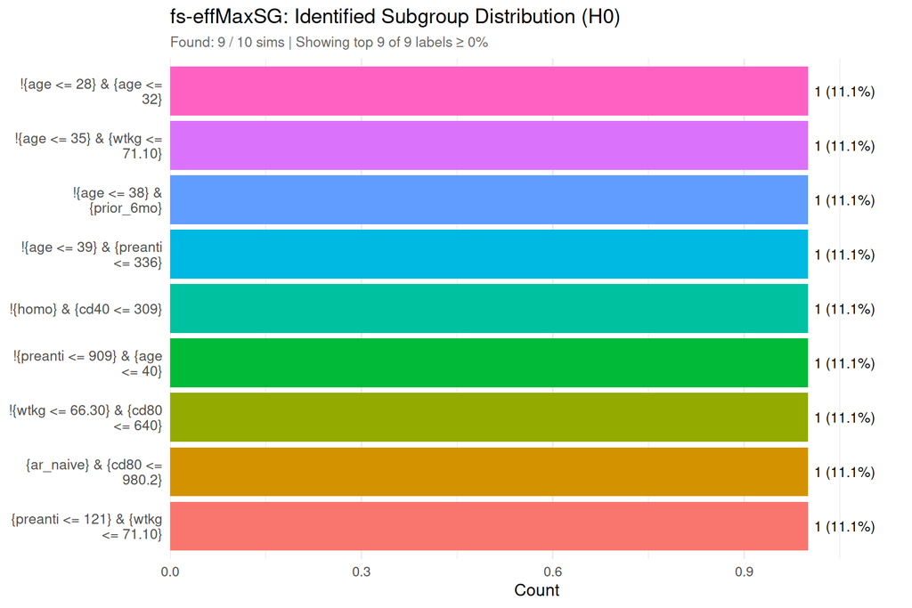

```r
flag_null <- results_null[results_null$analysis == FLAGSHIP_ARM, ]
if (nrow(flag_null) == 0L || sum(flag_null$any.H, na.rm = TRUE) == 0L) {
  cat(sprintf("*No detected subgroups for flagship arm `%s` under H0.*\n",
              FLAGSHIP_ARM))
} else {
  flag_null[["sg.def"]] <- vapply(flag_null[["sg.def"]], tidy_sg_def,
                                  character(1), USE.NAMES = FALSE)
  print(plot_sg_distribution(
    flag_null,
    any_col   = "any.H",
    label_col = "sg.def",
    min_pct   = sgdist_min_pct_null,
    top_k     = sgdist_top_k,
    title     = sprintf("%s: Identified Subgroup Distribution (H0)", FLAGSHIP_ARM)
  ))
}
```

# 10 Timing Summary

Timing Summary (wall-clock minutes)

Mode = demo; nsims_alt = 10, nsims_null = 10; total runtime = 3.53 min (0.06 hr)

| Component | H1 (alt) | H0 (null) |
| --- | --- | --- |
| Bootstrap (single-trial) | — | — |
| LOO cross-validation | — | — |
| Simulation loop | 1.88 | 1.65 |
| Subtotal | 1.88 | 1.65 |

Subtotals sum the three components per branch; '—' indicates a section that did not run (e.g. no harm subgroup identified, or run_loo = FALSE).

# 11 Appendix: The Pareto frontier in subgroup selection

# 12 The dominance rule

Both objectives — effect size and sample size — are *maximized*. A candidate $i$ is **dominated** if some other candidate $j$ is at least as good on both axes and strictly better on at least one:

$$\text{dominated}(i) \;\Longleftrightarrow\;
\exists\, j \neq i:\;
\mathrm{hr}_j \ge \mathrm{hr}_i \;\wedge\; N_j \ge N_i
\;\wedge\; (\mathrm{hr}_j > \mathrm{hr}_i \;\vee\; N_j > N_i).$$

The **Pareto frontier** is the set of non-dominated candidates — the upper-right boundary of the cloud. The package implements this as an $O(n^2)$ scan in `.pareto_dominated_xy()`; candidates with a missing effect or size are treated as dominated. The function below is a faithful mirror of that internal helper, kept local so this document renders without the package; the validation section confirms the two agree.

```r
# Mirror of forestsearch internal .pareto_dominated_xy(): both axes maximized.
dominated_xy <- function(x, y) {
  n <- length(x)
  dom <- logical(n)
  for (i in seq_len(n)) {
    if (is.na(x[i]) || is.na(y[i])) { dom[i] <- TRUE; next }
    for (j in seq_len(n)) {
      if (i == j) next
      if (is.na(x[j]) || is.na(y[j])) next
      if (x[j] >= x[i] && y[j] >= y[i] && (x[j] > x[i] || y[j] > y[i])) {
        dom[i] <- TRUE
        break
      }
    }
  }
  dom
}
```

# 13 How the band is formed

`.compute_inclusion_band()` builds two indicators and multiplies them:

```r
in_nbhd   <- (hr >= (1 - effect_neighborhood) * max(hr))   # 1-D effect band
in_pareto <- !dominated_xy(hr, N)                          # 2-D frontier
in_band   <- in_nbhd * in_pareto
```

Each `selection_rule` switches the two components on or off:

| `selection_rule` | `in_nbhd` | `in_pareto` | `in_band` is |
| --- | --- | --- | --- |
| `"neighborhood"` | active | all ones | the effect band only |
| `"pareto"` | all ones | active | the frontier only |
| `"both"` | active | active | their intersection |

For ratio measures stored on the log scale (GLM OR/IRR), `hr` is exponentiated before either test so the comparison is on the natural scale; Cox HR is already natural. The neighborhood floor is a *relative* tolerance: with `effect_neighborhood = 0.10` a candidate is in-band iff its effect is within 10% of the strongest effect among the survivors. Setting it to `0` collapses the band to a strict max-effect filter.

# 14 From inclusion to selection

`sort_subgroups()` orders the candidates by a five-key lexicographic sort and takes the top row. For `"hrMaxSG"` the key is

$$(-\,\texttt{in\_band},\; -N,\; -\texttt{Pcons},\; -\texttt{hr},\; K),$$

so: in-band candidates first; then the largest $N$; then higher consistency; then higher effect; then fewer factors. `"hrMinSG"` is identical except $N$ is minimized. Only `in_band` depends on `selection_rule` — the sort itself is fixed.

For the worked set, every rule that keeps `C` selects it (largest $N$ in the band), so the **top pick is `C`** under `"neighborhood"` and `"both"` alike; the rules differ only in whether `E` carries an in-band flag in the diagnostic table.

## 14.1 Where the rules genuinely diverge

The top selection differs only in a narrow corner: when two candidates **tie on the maximum band $N$**, because the sort breaks $N$-ties by consistency *before* effect, whereas Pareto dominance looks only at (effect, $N$).

```r
corner <- data.table(
  id    = c("T", "D"),
  Pcons = c(0.95, 0.80),
  hr    = c(2.30, 2.45),
  N     = c(150L, 150L),
  K     = c(1L,   1L)
)
corner[]
```

```
       id Pcons    hr     N     K
   <char> <num> <num> <int> <int>
1:      T  0.95  2.30   150     1
2:      D  0.80  2.45   150     1
```

`D` dominates `T` (equal $N$, higher HR). Under `"neighborhood"` both are in-band, they tie on $N$, and the consistency tier keeps the higher-`Pcons` candidate `T`. Under `"both"`, `T` is off the frontier and excluded, so the higher-effect `D` is selected.

```r
if (have_fs) {
  top_pick <- function(rule) {
    s <- forestsearch::sort_subgroups(
      data.table::copy(corner), "hrMaxSG",
      selection_rule = rule, effect_neighborhood = EFFECT_NEIGHBORHOOD)
    s$id[1L]
  }
  data.table(selection_rule = c("neighborhood", "both"),
             top_pick = vapply(c("neighborhood", "both"), top_pick, character(1)))
} else {
  cat("forestsearch not installed; expected: neighborhood -> T, both -> D.\n")
}
```

```
   selection_rule top_pick
           <char>   <char>
1:   neighborhood        T
2:           both        D
```

So `"both"` refuses to settle on a point another candidate beats on both axes, even when it won the consistency tie; `"neighborhood"` will keep the higher-consistency point.

# 15 Validation against the package

Confirm the local frontier and band computations agree with the shipped internals, and that `compute_pareto_frontier()` returns the expected non-dominated rows.

```r
if (have_fs) {
  .ok <- function(lbl, cond)
    cat(if (isTRUE(cond)) "PASS" else "FAIL", "-", lbl, "\n")

  dt_hn <- cands[, .(hr, N)]

  pkg_dom <- forestsearch:::pareto_dominated_flags(dt_hn)
  .ok("dominated flags match .pareto_dominated_xy mirror",
      identical(pkg_dom, cands$dominated))

  pkg_nbhd <- forestsearch:::.compute_inclusion_band(
    cands$hr, cands$N, "neighborhood", EFFECT_NEIGHBORHOOD)
  .ok("neighborhood band matches",
      identical(as.logical(pkg_nbhd), cands$in_nbhd))

  pkg_both <- forestsearch:::.compute_inclusion_band(
    cands$hr, cands$N, "both", EFFECT_NEIGHBORHOOD)
  .ok("both band matches in_nbhd & on_frontier",
      identical(as.logical(pkg_both), cands$in_both))

  fr <- forestsearch:::compute_pareto_frontier(dt_hn)
  .ok("compute_pareto_frontier returns the non-dominated set",
      setequal(fr$hr, cands[on_frontier == TRUE, hr]))
} else {
  cat("forestsearch not installed; validation skipped.\n")
}
```

```
PASS - dominated flags match .pareto_dominated_xy mirror
PASS - neighborhood band matches
PASS - both band matches in_nbhd & on_frontier
PASS - compute_pareto_frontier returns the non-dominated set
```

# 16 Practical guidance

- `"neighborhood"` (default) asks only “is the effect close to the best?” then maximizes $N$. It can keep a high-consistency candidate that another point beats on both effect and size.
- `"pareto"` removes the `effect_neighborhood` tuning parameter entirely and selects on the (effect, $N$) trade-off alone — but without the effect floor it will admit large-$N$, weak-effect points (like `F`) that the band is designed to exclude.
- `"both"` is the conservative choice: it keeps the effect floor *and* refuses dominated points. The in-band set under `"both"` is always a subset of the one under `"neighborhood"`.

The frontier here is an inclusion filter, not a stand-alone selection criterion: the chosen subgroup still comes from the five-key sort, and under `"hrMinSG"` the selected point may deliberately be $N$-dominated (small subgroups are preferred). For a post-hoc *reporting* view of the frontier independent of `sg_focus`, use `compute_pareto_frontier()` / `pareto_frontier_table()`.

## 16.1 Relationship to `dina_subgroup()`

The DINA `effMaxSG`/`effMinSG` foci reuse the same `.compute_inclusion_band()` core, but only with `selection_rule = "neighborhood"` — DINA’s univariate threshold candidates form a simple effect-versus-size trade-off where the 1-D band suffices. The `"pareto"`/`"both"` frontier variants are forestsearch-only today; extending them to DINA would be a deliberate addition.